# Python Data Preprocessing Example

## Keagan

We will start by importing relavent modules for processing the data, chiefly Pandas.

- Pandas for dataframe manipulation and filtering
- Datetime for simplified time processing as many time subsets are built in
- Numpy is a built-in dependency of Pandas, however we need to import it separately for array manipulation and to utilize it's linear algebra features.
- Matplotlib for plotting and graphic construction

```python
import pandas as pd
import datetime as dt
import numpy as np
import matplotlib.pyplot as plt
```

To load the data, we point the environment to the directory that contains the relevant file(s).

```python
# Load in data with a working directory change
%cd "/content/drive/MyDrive/Computer Science/CSCI436/Homework/Assignment-1"
```

```
/content/drive/MyDrive/Computer Science/CSCI436/Homework/Assignment-1
```

Next, the .csv is parsed and transformed into a mutable Pandas dataframe. To have the dates read in as datetime objects the `parse_dates` parameter is pointed at the column(s) that contain the relevant time information

```python
# Read the csv, use parse_date to format in datetime
df = pd.read_csv("GitHub-Data/crypto_github_events.csv", parse_dates = ['date'])
```

```python
# Verify the Dtypes
df.info()
```

```
<class 'pandas.core.frame.DataFrame'>
RangeIndex: 1172138 entries, 0 to 1172137
Data columns (total 4 columns):
 #   Column   Non-Null Count    Dtype
---  ------   --------------    -----
 0   date     1172138 non-null  datetime64[ns, UTC]
 1   actions  1172138 non-null  object
 2   userID   1172138 non-null  object
 3   repoID   1172138 non-null  object
dtypes: datetime64[ns, UTC](1), object(3)
memory usage: 35.8+ MB
```

To create our specified subset of 10 users that performed the most actions in 2016 we start by taking the subset of the year 2016. Next, we group the subset by their user ID's; since each row in the dataframe consitutes an action we can count each line in the dataframe as an "action". This allows us to use the `count()` function as our aggragator (similar to SQL) this yields each user's cumulative actions for the year of 2016. In this action the dataframe is sorted in descending order and cut to the first 10 users.

Once we have the subset of the top 10 users we are able to subset the dataframe containing only the year 2016 by user and month. This yields our targeted data, however the data is transposed and we need to unstack the data to get our desired result. Finally, we count the actions in the final aggragated dataframe and check that the match our first cumulative count.

The relevant data is outputted to a .csv and the nessessary plot is generated using the Pandas/Matplotlib interdependency. To yield the correct figure we need to again take the transpose of the dataframe so the data is in it's proper time-series orientation.

```python
# Subset the dataframe to the year 2016
df_2016  = df[df.date.dt.strftime('%Y') == '2016']

# Find the top 10 users by grouping on their ID's and counting their actions as the aggragate function
top_10 = df_2016.groupby(by = ['userID']).actions.count().sort_values(ascending=False).iloc[:10].index.to_list()

# Subset the dataframe by the top 10 users, then group by user and month again counting actions as the aggrate function
agg = df_2016[df_2016['userID'].isin(top_10)].groupby(['userID', df_2016.date.dt.strftime('%Y-%m')]).count()['actions'].unstack()

# Add the total actions taken as a new column
agg['Total'] = agg.sum(axis = 1)

# Sort the values in descending order
agg.sort_values(by = 'Total', ascending = False, inplace = True)

# verify that the Total matches the count found in top_10
df_2016.groupby(by = ['userID']).actions.count().sort_values(ascending=False).iloc[:10].values == agg.Total.values
```

```
array([ True,  True,  True,  True,  True,  True,  True,  True,  True,
        True])
```

```python
agg
```

| date userID | 2016-01 | 2016-02 | 2016-03 | 2016-04 | 2016-05 | 2016-06 | 2016-07 | 2016-08 | 2016-09 | 2016-10 | 2016-11 | 2016-12 | Total |
| --- | --- | --- | --- | --- | --- | --- | --- | --- | --- | --- | --- | --- | --- |
| 8iDsKCYEfcL4jeGKxNtPQg | 78.0 | 1292.0 | 745.0 | 738.0 | 1183.0 | 731.0 | 888.0 | 1188.0 | 1090.0 | 719.0 | 755.0 | 550.0 | 9957.0 |
| K3WbcDlZUBxBfx8Mv-twSg | 395.0 | 600.0 | 645.0 | 721.0 | 370.0 | 648.0 | 344.0 | 424.0 | 718.0 | 410.0 | 474.0 | 322.0 | 6071.0 |
| -Tf7mnYl8kygw0ZctlhfOw | 100.0 | 468.0 | 357.0 | 195.0 | 522.0 | 393.0 | 442.0 | 597.0 | 634.0 | 508.0 | 709.0 | 694.0 | 5619.0 |
| M5f7BOOVxgnr-XdzMo8bGQ | 523.0 | 196.0 | 402.0 | 429.0 | 285.0 | 379.0 | 257.0 | 412.0 | 461.0 | 234.0 | 261.0 | 261.0 | 4100.0 |
| yhHGzBppxhIRhPkWapTLJQ | 125.0 | 365.0 | 294.0 | 336.0 | 508.0 | 265.0 | 159.0 | 311.0 | 570.0 | 417.0 | 349.0 | 358.0 | 4057.0 |
| Qyz97YBv9rf-V3QYWhkSbw | NaN | NaN | NaN | 8.0 | 958.0 | 240.0 | 481.0 | 422.0 | 309.0 | 248.0 | 390.0 | 469.0 | 3525.0 |
| -a6UdIyZt2IMkKkd1Msv6g | 31.0 | 417.0 | 267.0 | 254.0 | 379.0 | 318.0 | 361.0 | 466.0 | 401.0 | 217.0 | 141.0 | 78.0 | 3330.0 |
| AIVdQMXja0fmjFk_ejf7ow | 164.0 | 179.0 | 254.0 | 372.0 | 335.0 | 452.0 | 196.0 | 367.0 | 236.0 | 100.0 | 270.0 | 255.0 | 3180.0 |
| Li47SClZy_BDxLTc0mN7bQ | 268.0 | 247.0 | 223.0 | 418.0 | 324.0 | 396.0 | 379.0 | 280.0 | 131.0 | 42.0 | 143.0 | 190.0 | 3041.0 |
| oVVUY8Nh5wNqJ0qLROKRkg | 194.0 | 154.0 | 186.0 | 245.0 | 269.0 | 204.0 | 248.0 | 313.0 | 252.0 | 185.0 | 336.0 | 343.0 | 2929.0 |

```python
# Save the dataframe in .csv format
agg.to_csv("monthly_volume.csv", encoding = 'utf-8')
```

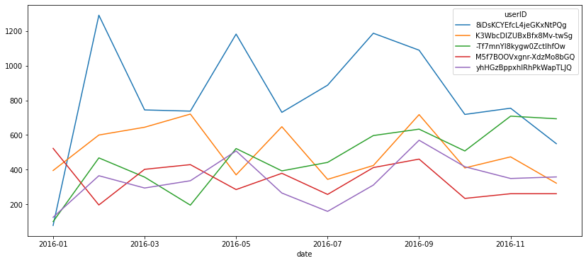

```python
# Pandas uses Matplotlib as a dependency
# Filter the dataframe to top 5, then take the transpose inorder to plot on the correct axes
agg.iloc[:5,:12].T.plot(figsize = (14,6))
```

For the statistics about the data I provided two methods: the first using functions implemented by Scikit-learn and secondly using linear algebra.

```python
# We can use sklearn to get a function that calculates cosine similarity

from sklearn.metrics.pairwise import cosine_similarity
print(f'Sklearn Cosine Similarity: \n {cosine_similarity(agg.iloc[:2,:12])} \n')

A = agg.iloc[:1,:12].values[0]
B = agg.iloc[1:2,:12].values[0]

# Calculate cosine similarity "by hand" to verify scikit function returns the correct answer
cosine = np.sum(A*B)/(np.linalg.norm(A)*np.linalg.norm(B))
print(f'"By Hand" Cosine Similarity: \n {cosine} \n')

# Repeat the above actions for the Euclidean distance

from sklearn.metrics.pairwise import euclidean_distances

print(f'Sklean Eucildean Distance: \n {euclidean_distances(agg.iloc[:2,:12])} \n')

euclidean = np.linalg.norm(A - B)

print(f'"By Hand" Eucildean Distance: \n {euclidean} \n')
```

```
Sklearn Cosine Similarity:
 [[1.         0.91812623]
 [0.91812623 1.        ]]

"By Hand" Cosine Similarity:
 0.9181262305329296

Sklean Eucildean Distance:
 [[   0.         1581.75282519]
 [1581.75282519    0.        ]]

"By Hand" Eucildean Distance:
 1581.7528251910917
```

# Correlation

As with the first part the numbers were calculated using a statistics library but this time Scipy, an underpinning of Scikit-learn, and "by hand". However, the "by hand" utilizes a built-in feature of Pandas. The pearson correlation between top 6 users is hard to visualize in dataframe format, so for easy access I plotted the results in a heatmap via Seaborn (another graphic creation library)

```python
from scipy.stats import pearsonr

_corr, pval = pearsonr(A,B)

print(_corr)

agg.iloc[:2,:12].T.corr(method = 'pearson')
```

```
0.20746421327063738
```

| userID | 8iDsKCYEfcL4jeGKxNtPQg | K3WbcDlZUBxBfx8Mv-twSg |
| --- | --- | --- |
| 8iDsKCYEfcL4jeGKxNtPQg | 1.000000 | 0.207464 |
| K3WbcDlZUBxBfx8Mv-twSg | 0.207464 | 1.000000 |

```python
agg.iloc[:6,:12].T.corr(method = 'pearson')
```

| userID | 8iDsKCYEfcL4jeGKxNtPQg | K3WbcDlZUBxBfx8Mv-twSg | -Tf7mnYl8kygw0ZctlhfOw | M5f7BOOVxgnr-XdzMo8bGQ | yhHGzBppxhIRhPkWapTLJQ | Qyz97YBv9rf-V3QYWhkSbw |
| --- | --- | --- | --- | --- | --- | --- |
| 8iDsKCYEfcL4jeGKxNtPQg | 1.000000 | 0.207464 | 0.493986 | -0.386258 | 0.579829 | 0.503629 |
| K3WbcDlZUBxBfx8Mv-twSg | 0.207464 | 1.000000 | -0.244449 | 0.389437 | 0.263534 | -0.652677 |
| -Tf7mnYl8kygw0ZctlhfOw | 0.493986 | -0.244449 | 1.000000 | -0.527445 | 0.569957 | 0.432994 |
| M5f7BOOVxgnr-XdzMo8bGQ | -0.386258 | 0.389437 | -0.527445 | 1.000000 | -0.190823 | -0.423934 |
| yhHGzBppxhIRhPkWapTLJQ | 0.579829 | 0.263534 | 0.569957 | -0.190823 | 1.000000 | 0.244609 |
| Qyz97YBv9rf-V3QYWhkSbw | 0.503629 | -0.652677 | 0.432994 | -0.423934 | 0.244609 | 1.000000 |

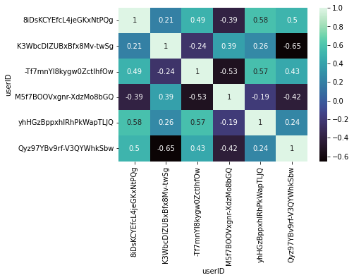

```python
import seaborn as sb

sb.heatmap(agg.iloc[:6,:12].T.corr(method = 'pearson'), cmap = 'mako', annot = True)
```